# Task 1

## Web scraping and analysis

This Jupyter notebook includes some code to get you started with web scraping. We will use a package called `BeautifulSoup` to collect the data from the web. Once you've collected your data and saved it into a local `.csv` file you should start with your analysis.

### Scraping data from Skytrax

If you visit [https://www.airlinequality.com] you can see that there is a lot of data there. For this task, we are only interested in reviews related to British Airways and the Airline itself.

If you navigate to this link: [https://www.airlinequality.com/airline-reviews/british-airways] you will see this data. Now, we can use `Python` and `BeautifulSoup` to collect all the links to the reviews and then to collect the text data on each of the individual review links.

```python
import requests
from bs4 import BeautifulSoup
import numpy as np
import pandas as pd
import seaborn as sns
import re, nltk
nltk.download('punkt')
import matplotlib.pyplot as plt
import string
from nltk.corpus import stopwords
nltk.download('stopwords')
from sklearn.feature_extraction.text import CountVectorizer, TfidfVectorizer
import warnings
warnings.filterwarnings('ignore')
```

```python
base_url = "https://www.airlinequality.com/airline-reviews/british-airways"
pages = 10
page_size = 100

reviews = []
aircraft = []
seat_type = []
route = []
recommended = []
df = pd.DataFrame()

# for i in range(1, pages + 1):
for i in range(1, pages + 1):

    rating = []
    category = []

    print(f"Scraping page {i}")

    # Create URL to collect links from paginated data
    url = f"{base_url}/page/{i}/?sortby=post_date%3ADesc&pagesize={page_size}"

    # Collect HTML data from this page
    response = requests.get(url)

    # Parse content
    content = response.content
    parsed_content = BeautifulSoup(content, 'html.parser')
    for para in parsed_content.find_all("div", {"class": "text_content"}):
        reviews.append(para.get_text())

    for para2 in parsed_content.find_all("div", {"class" : "review-stats"}):
        for para3 in para2.find_all('td',{'class' : 'review-value'}):
            rating.append(para3.get_text())
        recomend = rating[-1]
        rating = rating[:-1]

        for para4 in para2.find_all('td',{'class' : 'review-rating-stars stars'}):
            para5 = len(para4.find_all('span', {'class' : 'star fill'}))
            rating.append(para5)
        rating.append(recomend)
        #print(rating)

        for para6 in para2.find_all('td',{'class' : 'review-rating-header'}):
            category.append(para6.get_text())

        #print(category)
        # Create the records from both list, using zip and dict calls.

        # Build the dataframe from the dictionary.
        data_dict = pd.DataFrame([rating], columns=category)
        df = df.append(data_dict, ignore_index=True).reset_index(drop=True)
        #print(df)
        rating = []
        category = []

    print(f"   ---> {len(reviews)} total reviews")

df["reviews"] = reviews
```

```
Scraping page 1
   ---> 100 total reviews
Scraping page 2
   ---> 200 total reviews
Scraping page 3
   ---> 300 total reviews
Scraping page 4
   ---> 400 total reviews
Scraping page 5
   ---> 500 total reviews
Scraping page 6
   ---> 600 total reviews
Scraping page 7
   ---> 700 total reviews
Scraping page 8
   ---> 800 total reviews
Scraping page 9
   ---> 900 total reviews
Scraping page 10
   ---> 1000 total reviews
```

```python
df.head()
```

|  | Type Of Traveller | Seat Type | Route | Date Flown | Seat Comfort | Cabin Staff Service | Food & Beverages | Inflight Entertainment | Ground Service | Wifi & Connectivity | Value For Money | Recommended | Aircraft | reviews |
| --- | --- | --- | --- | --- | --- | --- | --- | --- | --- | --- | --- | --- | --- | --- |
| 0 | Couple Leisure | Premium Economy | Dallas to Madrid via London | May 2023 | 1.0 | 1.0 | 1.0 | 1.0 | 1.0 | 1.0 | 1 | no | NaN | Not Verified \| Top Ten REASONS to not use Brit... |
| 1 | Couple Leisure | Economy Class | London to Valencia | March 2023 | 4.0 | 4.0 | NaN | NaN | 5.0 | NaN | 4 | yes | NaN | Not Verified \| Easy check in on the way to He... |
| 2 | Solo Leisure | Economy Class | London to Glasgow | May 2023 | 5.0 | 5.0 | 5.0 | NaN | 5.0 | NaN | 5 | yes | A320 | ✅ Trip Verified \| Online check in worked fine... |
| 3 | Business | Business Class | London Heathrow to Malaga | May 2023 | 2.0 | 2.0 | 3.0 | 1.0 | 1.0 | 1.0 | 1 | no | A320 Finnair | ✅ Trip Verified \|. The BA first lounge at Term... |
| 4 | Couple Leisure | Business Class | London to Nice | May 2023 | 2.0 | 3.0 | 3.0 | NaN | 4.0 | 1.0 | 1 | no | A319 | Not Verified \| Paid a quick visit to Nice yest... |

```python
df.to_csv("BA_reviews.csv",index=False)
```

Congratulations! Now you have your dataset for this task! The loops above collected 1000 reviews by iterating through the paginated pages on the website. However, if you want to collect more data, try increasing the number of pages!

The next thing that you should do is clean this data to remove any unnecessary text from each of the rows. For example, "✅ Trip Verified" can be removed from each row if it exists, as it's not relevant to what we want to investigate.

```python
df=pd.read_csv('/kaggle/working/BA_reviews.csv')
df
```

|  | Type Of Traveller | Seat Type | Route | Date Flown | Seat Comfort | Cabin Staff Service | Food & Beverages | Inflight Entertainment | Ground Service | Wifi & Connectivity | Value For Money | Recommended | Aircraft | reviews |
| --- | --- | --- | --- | --- | --- | --- | --- | --- | --- | --- | --- | --- | --- | --- |
| 0 | Couple Leisure | Premium Economy | Dallas to Madrid via London | May 2023 | 1.0 | 1.0 | 1.0 | 1.0 | 1.0 | 1.0 | 1 | no | NaN | Not Verified \| Top Ten REASONS to not use Brit... |
| 1 | Couple Leisure | Economy Class | London to Valencia | March 2023 | 4.0 | 4.0 | NaN | NaN | 5.0 | NaN | 4 | yes | NaN | Not Verified \| Easy check in on the way to He... |
| 2 | Solo Leisure | Economy Class | London to Glasgow | May 2023 | 5.0 | 5.0 | 5.0 | NaN | 5.0 | NaN | 5 | yes | A320 | ✅ Trip Verified \| Online check in worked fine... |
| 3 | Business | Business Class | London Heathrow to Malaga | May 2023 | 2.0 | 2.0 | 3.0 | 1.0 | 1.0 | 1.0 | 1 | no | A320 Finnair | ✅ Trip Verified \|. The BA first lounge at Term... |
| 4 | Couple Leisure | Business Class | London to Nice | May 2023 | 2.0 | 3.0 | 3.0 | NaN | 4.0 | 1.0 | 1 | no | A319 | Not Verified \| Paid a quick visit to Nice yest... |
| ... | ... | ... | ... | ... | ... | ... | ... | ... | ... | ... | ... | ... | ... | ... |
| 995 | Business | Economy Class | Aberdeen to Boston via London | July 2018 | 2.0 | 4.0 | 4.0 | 5.0 | 4.0 | 4.0 | 3 | yes | NaN | ✅ Trip Verified \| Aberdeen to Boston via Lond... |
| 996 | Solo Leisure | Economy Class | London to Hamburg | June 2018 | 4.0 | 3.0 | NaN | NaN | 5.0 | NaN | 3 | yes | A319 | ✅ Trip Verified \| London to Hamburg. Baggage ... |
| 997 | Family Leisure | Premium Economy | London Heathrow to Hong Kong | July 2018 | 3.0 | 3.0 | 2.0 | 3.0 | 1.0 | 2.0 | 2 | no | NaN | ✅ Trip Verified \| Flew London Heathrow to Hong... |
| 998 | Couple Leisure | Economy Class | London to Istanbul | June 2018 | 3.0 | 3.0 | 1.0 | 1.0 | 1.0 | NaN | 2 | no | NaN | ✅ Trip Verified \| Flew to Istanbul with Britis... |
| 999 | Solo Leisure | Economy Class | Munich to London Heathrow | July 2018 | 4.0 | 4.0 | 2.0 | NaN | 5.0 | NaN | 3 | yes | A320 | ✅ Trip Verified \| Munich to London Heathrow w... |

1000 rows × 14 columns

```python
df.shape
```

```
(1000, 14)
```

```python
df.info()
```

```
<class 'pandas.core.frame.DataFrame'>
RangeIndex: 1000 entries, 0 to 999
Data columns (total 14 columns):
 #   Column                  Non-Null Count  Dtype
---  ------                  --------------  -----
 0   Type Of Traveller       999 non-null    object
 1   Seat Type               1000 non-null   object
 2   Route                   997 non-null    object
 3   Date Flown              1000 non-null   object
 4   Seat Comfort            922 non-null    float64
 5   Cabin Staff Service     916 non-null    float64
 6   Food & Beverages        798 non-null    float64
 7   Inflight Entertainment  545 non-null    float64
 8   Ground Service          947 non-null    float64
 9   Wifi & Connectivity     264 non-null    float64
 10  Value For Money         1000 non-null   int64
 11  Recommended             1000 non-null   object
 12  Aircraft                570 non-null    object
 13  reviews                 1000 non-null   object
dtypes: float64(6), int64(1), object(7)
memory usage: 109.5+ KB
```

```python
df.isna().sum()
```

```
Type Of Traveller           1
Seat Type                   0
Route                       3
Date Flown                  0
Seat Comfort               78
Cabin Staff Service        84
Food & Beverages          202
Inflight Entertainment    455
Ground Service             53
Wifi & Connectivity       736
Value For Money             0
Recommended                 0
Aircraft                  430
reviews                     0
dtype: int64
```

```python
remove_text = ['✅ Trip Verified |', 'Not Verified |']

for i in range(len(df['reviews'])):
    for j in remove_text:
        if j in df['reviews'][i]:
            df['reviews'] = df['reviews'].str.replace(j,'')
```

```python
df
```

|  | Type Of Traveller | Seat Type | Route | Date Flown | Seat Comfort | Cabin Staff Service | Food & Beverages | Inflight Entertainment | Ground Service | Wifi & Connectivity | Value For Money | Recommended | Aircraft | reviews |
| --- | --- | --- | --- | --- | --- | --- | --- | --- | --- | --- | --- | --- | --- | --- |
| 0 | Couple Leisure | Premium Economy | Dallas to Madrid via London | May 2023 | 1.0 | 1.0 | 1.0 | 1.0 | 1.0 | 1.0 | 1 | no | NaN | \| Top Ten REASONS to not use British Airways T... |
| 1 | Couple Leisure | Economy Class | London to Valencia | March 2023 | 4.0 | 4.0 | NaN | NaN | 5.0 | NaN | 4 | yes | NaN | \| Easy check in on the way to Heathrow. The f... |
| 2 | Solo Leisure | Economy Class | London to Glasgow | May 2023 | 5.0 | 5.0 | 5.0 | NaN | 5.0 | NaN | 5 | yes | A320 | \| Online check in worked fine. Quick security... |
| 3 | Business | Business Class | London Heathrow to Malaga | May 2023 | 2.0 | 2.0 | 3.0 | 1.0 | 1.0 | 1.0 | 1 | no | A320 Finnair | \|. The BA first lounge at Terminal 5 was a zo... |
| 4 | Couple Leisure | Business Class | London to Nice | May 2023 | 2.0 | 3.0 | 3.0 | NaN | 4.0 | 1.0 | 1 | no | A319 | \| Paid a quick visit to Nice yesterday from He... |
| ... | ... | ... | ... | ... | ... | ... | ... | ... | ... | ... | ... | ... | ... | ... |
| 995 | Business | Economy Class | Aberdeen to Boston via London | July 2018 | 2.0 | 4.0 | 4.0 | 5.0 | 4.0 | 4.0 | 3 | yes | NaN | \| Aberdeen to Boston via London Heathrow. I f... |
| 996 | Solo Leisure | Economy Class | London to Hamburg | June 2018 | 4.0 | 3.0 | NaN | NaN | 5.0 | NaN | 3 | yes | A319 | \| London to Hamburg. Baggage self-check-in wa... |
| 997 | Family Leisure | Premium Economy | London Heathrow to Hong Kong | July 2018 | 3.0 | 3.0 | 2.0 | 3.0 | 1.0 | 2.0 | 2 | no | NaN | \| Flew London Heathrow to Hong Kong with Briti... |
| 998 | Couple Leisure | Economy Class | London to Istanbul | June 2018 | 3.0 | 3.0 | 1.0 | 1.0 | 1.0 | NaN | 2 | no | NaN | \| Flew to Istanbul with British Airways on 5th... |
| 999 | Solo Leisure | Economy Class | Munich to London Heathrow | July 2018 | 4.0 | 4.0 | 2.0 | NaN | 5.0 | NaN | 3 | yes | A320 | \| Munich to London Heathrow with British Airw... |

1000 rows × 14 columns

```python
df['Recommended'].unique()
```

```
array(['no', 'yes'], dtype=object)
```

```python
df.describe().T
```

|  | count | mean | std | min | 25% | 50% | 75% | max |
| --- | --- | --- | --- | --- | --- | --- | --- | --- |
| Seat Comfort | 922.0 | 2.835141 | 1.384316 | 1.0 | 2.0 | 3.0 | 4.0 | 5.0 |
| Cabin Staff Service | 916.0 | 3.245633 | 1.522772 | 1.0 | 2.0 | 3.0 | 5.0 | 5.0 |
| Food & Beverages | 798.0 | 2.749373 | 1.480901 | 1.0 | 1.0 | 3.0 | 4.0 | 5.0 |
| Inflight Entertainment | 545.0 | 2.809174 | 1.455311 | 1.0 | 1.0 | 3.0 | 4.0 | 5.0 |
| Ground Service | 947.0 | 2.743400 | 1.539695 | 1.0 | 1.0 | 3.0 | 4.0 | 5.0 |
| Wifi & Connectivity | 264.0 | 2.280303 | 1.536944 | 1.0 | 1.0 | 1.0 | 4.0 | 5.0 |
| Value For Money | 1000.0 | 2.512000 | 1.487975 | 1.0 | 1.0 | 2.0 | 4.0 | 5.0 |

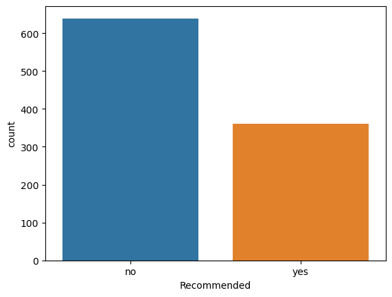

```python
sns.countplot(x="Recommended", data=df)
```

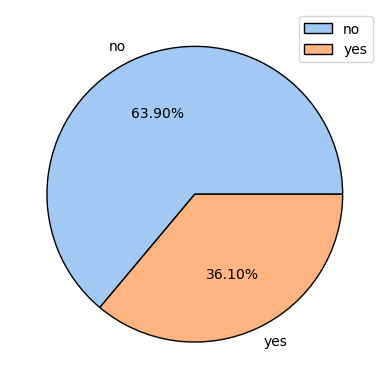

```python
soc = df.groupby('Recommended')['reviews'].count().reset_index()
plt.pie(soc['reviews'], labels = soc['Recommended'], autopct='%.2f%%',colors = sns.color_palette('pastel'),
          wedgeprops={"edgecolor":"k"},)
plt.legend()
plt.show()
```

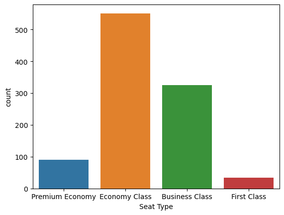

```python
sns.countplot(x="Seat Type", data=df)
```

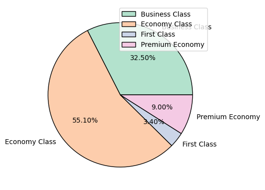

```python
seat_type = df.groupby('Seat Type')['reviews'].count().reset_index()
plt.pie(seat_type['reviews'], labels = seat_type['Seat Type'], autopct='%.2f%%',colors = sns.color_palette('Pastel2'),
          wedgeprops={"edgecolor":"k"},)
plt.legend()
plt.show()
```

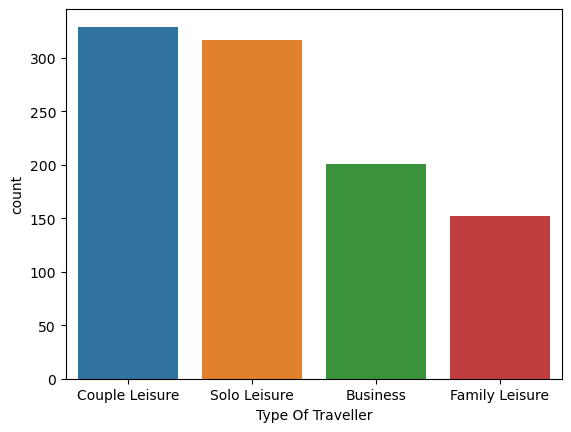

```python
sns.countplot(x="Type Of Traveller", data=df)
```

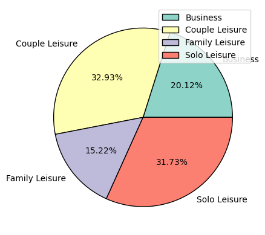

```python
traveller_type = df.groupby('Type Of Traveller')['reviews'].count().reset_index()
plt.pie(traveller_type['reviews'], labels = traveller_type['Type Of Traveller'], autopct='%.2f%%',colors = sns.color_palette('Set3'),
          wedgeprops={"edgecolor":"k"},)
plt.legend()
plt.show()
```

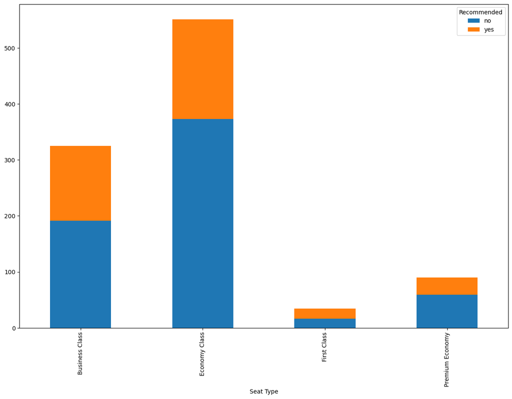

```python
seat_rec = df.groupby(['Seat Type', 'Recommended']).size()
seat_rec.unstack().plot(kind='bar', stacked=True, figsize=(15,10))
```

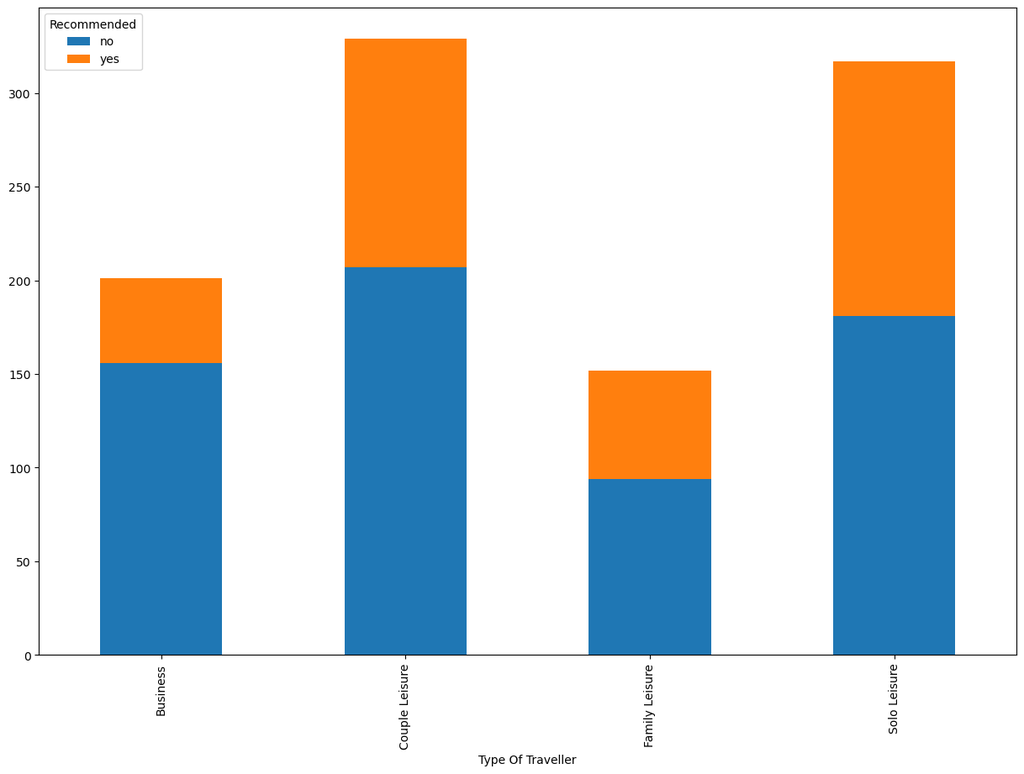

```python
travel_type_rec = df.groupby(['Type Of Traveller', 'Recommended']).size()
travel_type_rec.unstack().plot(kind='bar', stacked=True, figsize=(15,10))
```

```
Total number of recommendation for each seat type
  Seat Type
Economy Class      551
Business Class     325
Premium Economy     90
First Class         34
Name: Recommended, dtype: int64
```

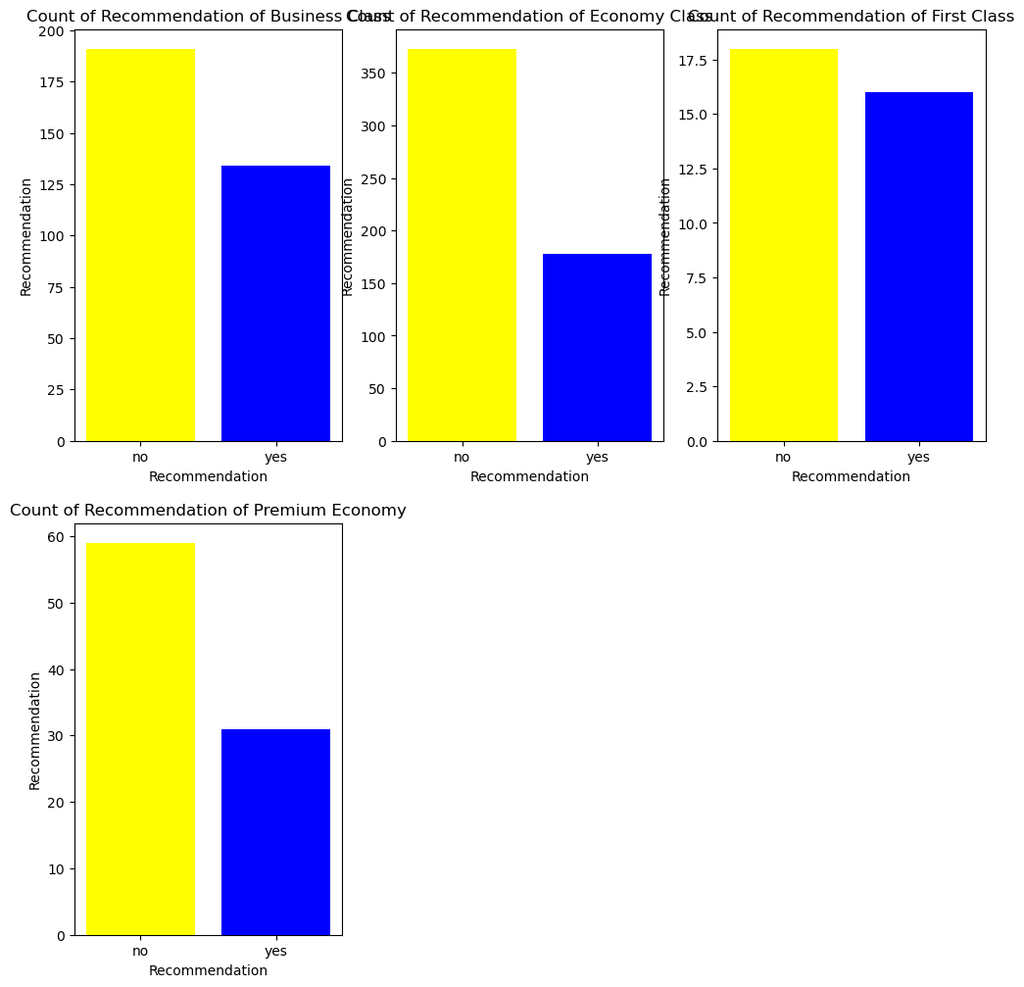

```python
print("Total number of recommendation for each seat type \n ",df.groupby('Seat Type')['Recommended'].count().sort_values(ascending=False))
seat= ['Business Class','Economy Class','First Class','Premium Economy']
plt.figure(1,figsize=(12, 12))
for i in seat:
    indices= seat.index(i)
    plt.subplot(2,3,indices+1)
    new_df=df[df['Seat Type']==i]
    count=new_df['Recommended'].value_counts()
    Index = [1,2]
    plt.bar(Index,count, color=['yellow', 'blue'])
    plt.xticks(Index,['no','yes'])
    plt.ylabel('Recommendation')
    plt.xlabel('Recommendation')
    plt.title('Count of Recommendation of '+i)
```

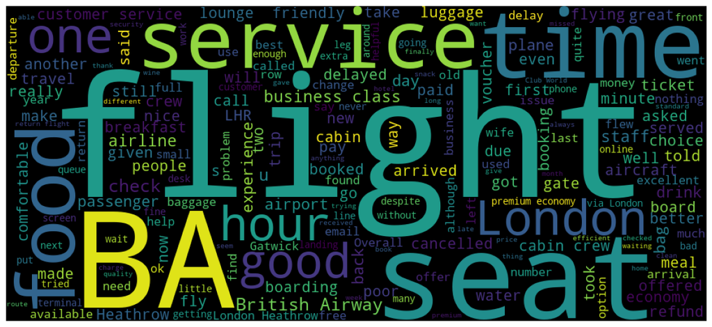

```python
review_word = []

for i in df['reviews'] :
    a = i.split(' ')
    for x in a:
        review_word.append(x)

unique_string = (" ").join(review_word)

wc = WordCloud(width = 1000, height = 450, background_color = 'black').generate(unique_string)
plt.figure(figsize=(15,8))
plt.imshow(wc)
plt.axis("off")
plt.show()
```